# Reproducible Research: Peer Assessment 1

This is an analysis of movement data from a wearable device. It looks at total number of steps, on a daily basis, and activity at different times of day. The total steps are checked again after imputing values for missing measurements. Finally, activity patterns are compared between weekdays and weekends.

## Loading and preprocessing the data

The data come from a zip file assumed to be available in the working directory. The actual data file is extracted from the zip file and loaded. The date column is converted from a character field to a Date, and a new column is added representing the interval as a POSIXct time.

```r
## Pull in needed packages
suppressWarnings(require(dplyr))
suppressWarnings(require(data.table))
suppressWarnings(require(ggplot2))
suppressWarnings(require(scales))


## Set up constants
tempdir<-"./tempdata"
zipfile<-"activity.zip"
targetfile<-"activity.csv"
fullfile<-paste(tempdir,targetfile,sep="/")

## Check for data file and pull it in.
if( !file.exists(zipfile)){
        stop("File activity.zip required in working directory.")
}

## Read in the data
if(!file.exists(tempdir))
        dir.create(tempdir)
unzip(zipfile=zipfile, files=targetfile, exdir=tempdir)
rawdata<-tbl_df(read.csv(fullfile, stringsAsFactors=FALSE)) %>%
        mutate(date=as.Date(date,"%Y-%m-%d")) %>%
        mutate(hourMin=as.POSIXct(strptime(sprintf("%04d",interval),"%H%M")))
```

## What is mean total number of steps taken per day?

Compute the total number of steps for each day, then find the mean and median of this total.

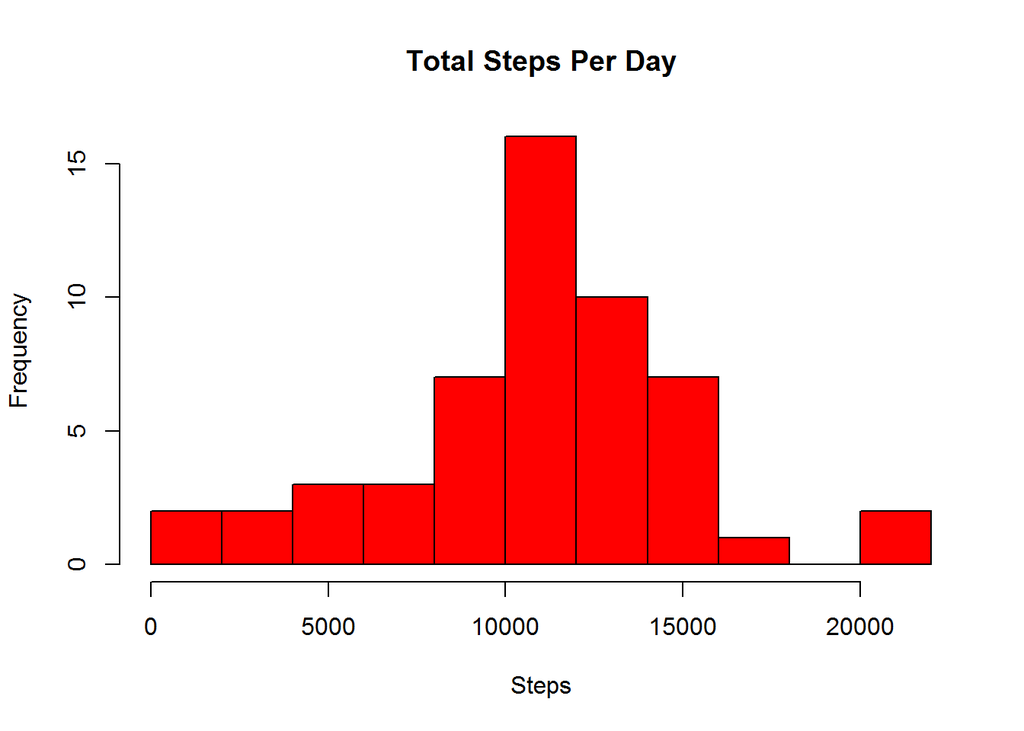

```r
stepsPerDay<-filter(rawdata, complete.cases(rawdata)) %>%
        group_by(date) %>%
        summarize(totalSteps=sum(steps))

averageSteps<-sprintf("%7.2f",mean(stepsPerDay$totalSteps,na.rm=TRUE))
medianSteps<-sprintf("%7.2f",median(stepsPerDay$totalSteps,na.rm=TRUE))

hist(stepsPerDay$totalSteps,breaks=10,col="red",main="Total Steps Per Day", xlab="Steps")
```

The mean total number of steps for the sample is 10766.19.

The median total number of steps for the sample is 10765.00.

## What is the average daily activity pattern?

For each interval, represented as a POSIXct, determine the average number of steps. From this, find the interval with the highest number.

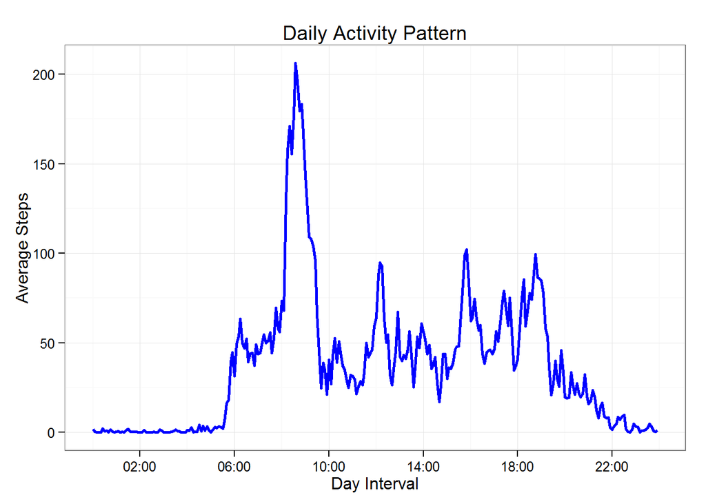

```r
activityPattern<-filter(rawdata, complete.cases(rawdata)) %>%
        group_by(hourMin) %>%
        summarize(averageSteps=mean(steps,na.rm=TRUE))

topInterval<-filter(activityPattern,averageSteps==max(averageSteps))%>%
        inner_join(rawdata,by="hourMin")%>%
        select(interval,hourMin,averageSteps)%>%
        distinct()


ggplot(
        data=activityPattern,
        aes(x=hourMin,y=averageSteps))+
        geom_line(col="blue",size=1)+theme_bw()+
        scale_x_datetime(breaks="4 hours", labels=date_format("%H%:%M"))+
        xlab("Day Interval")+ylab("Average Steps")+ggtitle("Daily Activity Pattern")
```

### Top Interval

The interval with the highest average steps across all days is 835 (08:35) with an average of 206.1698113 steps.

## Imputing missing values

### Quantify

There are a number of missing values for the step measurement. The first step is to quantify, then values will be assigned to them.

```r
missing.date<-sum(is.na(rawdata$date))
missing.interval<-sum(is.na(rawdata$interval))
missing.steps<-sum(is.na(rawdata$steps))
```

Missing values for the data set:

- Date: 0
- Interval: 0
- Steps: 2304

### Assign Values

Use the average steps for each interval, computed above, to supply missing values and repeat the daily step total analysis to see how it changes.

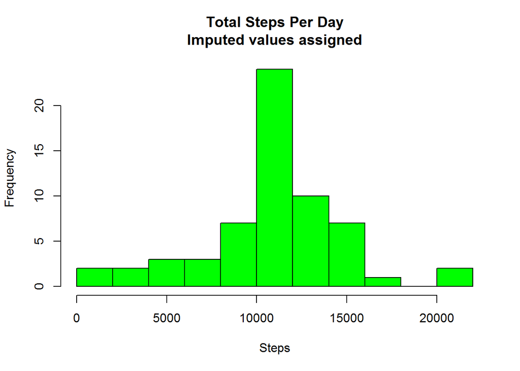

```r
imputeActivity<-rawdata %>%
        inner_join(activityPattern, by="hourMin") %>%
        mutate(imputedSteps=ifelse(is.na(steps),averageSteps,steps))

## Analysis of steps per day
imputedStepsPerDay<-imputeActivity %>%
        group_by(date) %>%
        summarize(totalSteps=sum(imputedSteps))


averageStepsImputed<-sprintf("%7.2f",mean(imputedStepsPerDay$totalSteps))
medianStepsImputed<-sprintf("%7.2f",median(imputedStepsPerDay$totalSteps))

hist(imputedStepsPerDay$totalSteps,breaks=10,col="green",main="Total Steps Per Day\nImputed values assigned", xlab="Steps")
```

## Are there differences in activity patterns between weekdays and weekends?

### Add a Factor

First, a new factor variable is added to the data set to differentiate week days from weekend days.

```r
## Add a factor variable to the data
imputeActivity<-imputeActivity %>%
        mutate(weekPart=as.factor(
                ifelse(weekdays(date) %in% c("Saturday","Sunday"),"Weekend","Weekday")))
```

### Look at the results

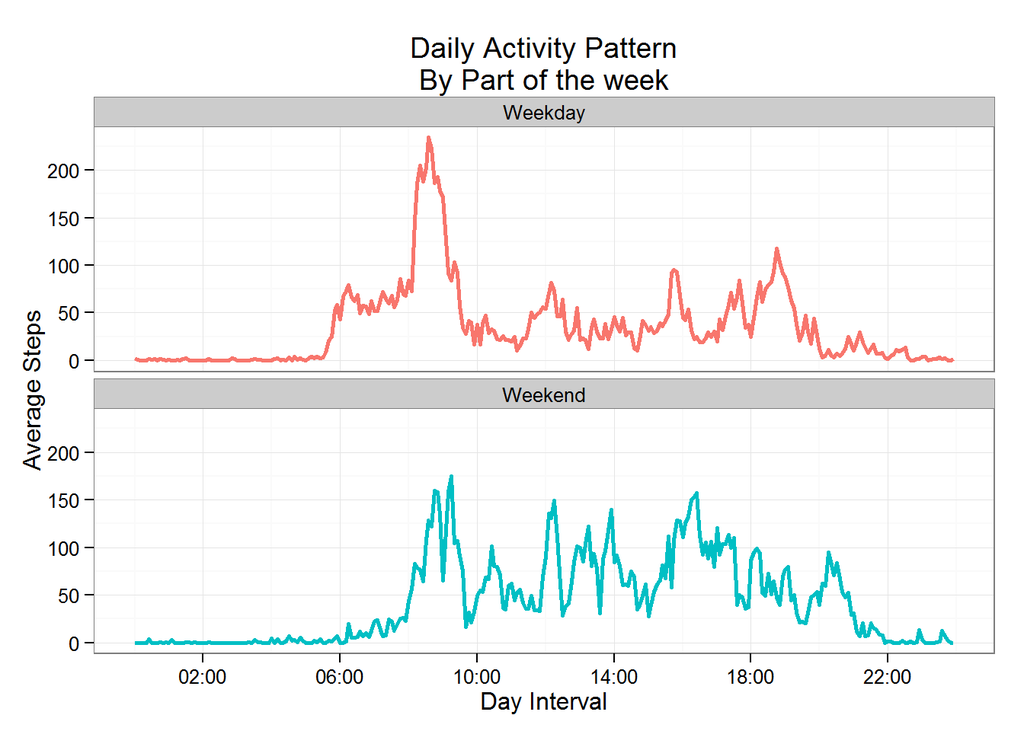

```r
## Compute average steps by part of the week.
weekPartPattern<-imputeActivity %>%
        group_by(weekPart,hourMin) %>%
        summarize(averageSteps=mean(steps, na.rm=TRUE))

ggplot(
        data=weekPartPattern,
        aes(x=hourMin,y=averageSteps,col=weekPart))+
        geom_line(size=1)+
        theme_bw()+theme(legend.position="none")+
        facet_wrap(~weekPart,nrow=2)+
        scale_x_datetime(breaks="4 hours", labels=date_format("%H%:%M"))+
        xlab("Day Interval")+ylab("Average Steps")+
        ggtitle("Daily Activity Pattern\nBy Part of the week")
```

### Observations

There is a difference between weekdays and weekends. On weekdays, the activity starts earlier, but is lower in the middle of the day. The weekends have elevated activity across much of the day.

## Clean up files and directory.

```r
file.remove(fullfile)
```

```
## [1] TRUE
```

```r
unlink(tempdir)
```